# CMSC320 Final Project Austin Le

## Final Project on Pollution in the U.S.

Austin Le

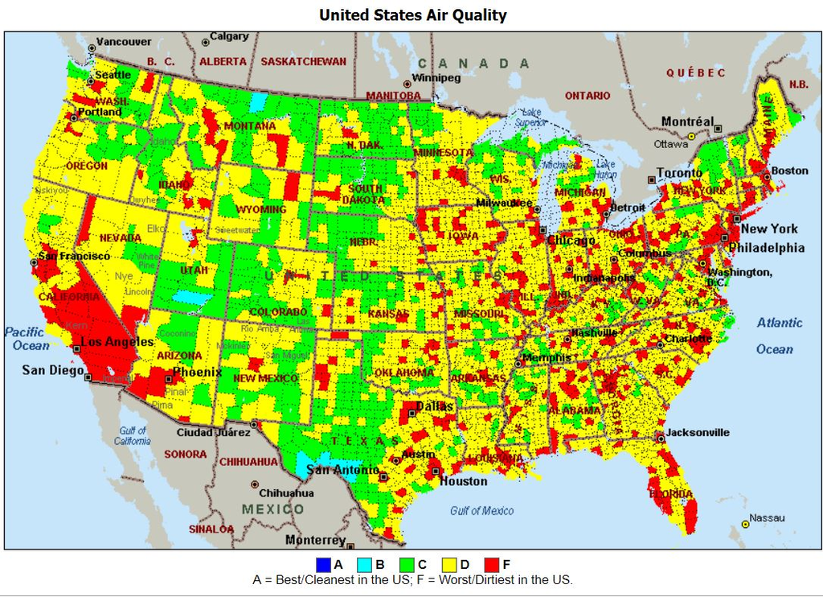

Image of United State Map of Air Quality Index

Currently in today’s society pollution and the environment have been important subjects. As society continues to develop pollution continues to increases which causes a concern for climate change and and the loss of biodiversity. Mine and your opinions on climate change and biodiversity are our own, but I have provided some articles to provide more background on the effects of pollution and definitions of climate change and biodiversity. For this tutorial we will be looking at a dataset that provides us with the U.S.’s pollution statistics from 2000-2016 taken from the EPA’s website.

## Background information

https://www.epa.gov/clean-air-act-overview/air-pollution-current-and-future-challenges  
https://en.wikipedia.org/wiki/Biodiversity  
https://climate.nasa.gov/  
https://airnow.gov/index.cfm?action=aqibasics.aqi

## Pollutants we will be observing

http://www.environment.gov.au/protection/publications/factsheet-sulfur-dioxide-so2  
https://www.epa.gov/ozone-pollution  
https://www.epa.gov/co-pollution  
https://www.epa.gov/no2-pollution

## Steps for this tutorial:

We will be walking through the entire dat science pipeline.  
1) Data Curation, Parsing, and Management  
2) Exploratory Data Analysis  
3) Hypothesis Testing and Machine Learning  
4) Conclusion based on testing/results

We will be conducting this tutorial in R (https://www.r-project.org/). Using Rstudio for your development environment to write code and manage libraries is recommended (https://www.rstudio.com/).

## 1) Data Curation

The first step of this tutorial is data curation, parsing, and management. As with this tutorial, we will be focusing on pollution in the U.S., so we will import a dataset in the form of a CSV (comma-separated values) file from this link: https://www.kaggle.com/sogun3/uspollution/data. Depending on what kind of analysis you want to do on your data you will have to parse and manage it accordingly. There may be information that you don’t need and can be removed, NaN values that you will have to decide how to handle, column headers are values, not variable names (gather), multiple variables stored in one column (split), and the list goes on.The data before you clean it can be considered messy data. There are many different techniques that you can use to parse and manage your data, but we will be using the concept of tidy data. The links below will give you more information on tidy data.

https://vita.had.co.nz/papers/tidy-data.pdf  
http://www.hcbravo.org/IntroDataSci/bookdown-notes/tidying-data.html

```r
library(tidyverse)
#We will be using R's read_csv function from the readr library to read our csv file to create a dataframe. We'll call head on our df to take a look at the data.

pollution_tab <- read_csv("C:/Users/Administrator/Documents/Duy documents/UMD Spring18 (CURRENT)/CMSC320/pollution_us_2000_2016.csv")
```

```r
#We'll take a look at our data
pollution_tab
```

```
## # A tibble: 1,746,661 x 29
##       X1 `State Code` `County Code` `Site Num` Address  State County City
##    <int>        <int>         <int>      <int> <chr>    <chr> <chr>  <chr>
##  1     0            4            13       3002 1645 E ~ Ariz~ Maric~ Phoe~
##  2     1            4            13       3002 1645 E ~ Ariz~ Maric~ Phoe~
##  3     2            4            13       3002 1645 E ~ Ariz~ Maric~ Phoe~
##  4     3            4            13       3002 1645 E ~ Ariz~ Maric~ Phoe~
##  5     4            4            13       3002 1645 E ~ Ariz~ Maric~ Phoe~
##  6     5            4            13       3002 1645 E ~ Ariz~ Maric~ Phoe~
##  7     6            4            13       3002 1645 E ~ Ariz~ Maric~ Phoe~
##  8     7            4            13       3002 1645 E ~ Ariz~ Maric~ Phoe~
##  9     8            4            13       3002 1645 E ~ Ariz~ Maric~ Phoe~
## 10     9            4            13       3002 1645 E ~ Ariz~ Maric~ Phoe~
## # ... with 1,746,651 more rows, and 21 more variables: `Date
## #   Local` <date>, `NO2 Units` <chr>, `NO2 Mean` <dbl>, `NO2 1st Max
## #   Value` <dbl>, `NO2 1st Max Hour` <int>, `NO2 AQI` <int>, `O3
## #   Units` <chr>, `O3 Mean` <dbl>, `O3 1st Max Value` <dbl>, `O3 1st Max
## #   Hour` <int>, `O3 AQI` <int>, `SO2 Units` <chr>, `SO2 Mean` <dbl>, `SO2
## #   1st Max Value` <dbl>, `SO2 1st Max Hour` <int>, `SO2 AQI` <dbl>, `CO
## #   Units` <chr>, `CO Mean` <dbl>, `CO 1st Max Value` <dbl>, `CO 1st Max
## #   Hour` <int>, `CO AQI` <dbl>
```

```r
pollution_tab <- na.omit(pollution_tab)
#Now we'll take a look at the variable names and remove the ones we do not need
names(pollution_tab)
```

```
##  [1] "X1"                "State Code"        "County Code"
##  [4] "Site Num"          "Address"           "State"
##  [7] "County"            "City"              "Date Local"
## [10] "NO2 Units"         "NO2 Mean"          "NO2 1st Max Value"
## [13] "NO2 1st Max Hour"  "NO2 AQI"           "O3 Units"
## [16] "O3 Mean"           "O3 1st Max Value"  "O3 1st Max Hour"
## [19] "O3 AQI"            "SO2 Units"         "SO2 Mean"
## [22] "SO2 1st Max Value" "SO2 1st Max Hour"  "SO2 AQI"
## [25] "CO Units"          "CO Mean"           "CO 1st Max Value"
## [28] "CO 1st Max Hour"   "CO AQI"
```

```r
pollution_tab <- pollution_tab[-c(1:5,7:8,10,12:13,15,17:18,20,22:23,25,27:28)]
```

Another way we can tidy data is change all the state names to their abbreviations, so that when we graph them later on readability will be much better. The units for O3 and CO are in parts per million however, the units for NO2 and SO2 are in parts per billion so we are going to multiply all the mean values of O3 and CO by 1000 to have a standard unit of parts per billion. This way our analysis of data will be correct since we are compaing the same units for all pollutants.

```r
pollution_tab$State <- state.abb[match(pollution_tab$State,state.name)]
pollution_tab$'O3 Mean' <- pollution_tab$'O3 Mean'*1000
pollution_tab$'CO Mean' <- pollution_tab$'CO Mean'*1000
```

The dataframe also provides us with the full date of each collection, however we are only interested in the pollution by year. We will extract only the year from the datetime and drop the day and month.

```r
pollution_tab$"Date Local" <- format(as.Date(pollution_tab$"Date Local", format="%d/%m/%Y"),"%Y")
```

```r
#Renaming the column to Year
colnames(pollution_tab)[2] <- "Year"
names(pollution_tab)
```

```
##  [1] "State"    "Year"     "NO2 Mean" "NO2 AQI"  "O3 Mean"  "O3 AQI"
##  [7] "SO2 Mean" "SO2 AQI"  "CO Mean"  "CO AQI"
```

```r
head(pollution_tab)
```

```
## # A tibble: 6 x 10
##   State Year  `NO2 Mean` `NO2 AQI` `O3 Mean` `O3 AQI` `SO2 Mean` `SO2 AQI`
##   <chr> <chr>      <dbl>     <int>     <dbl>    <int>      <dbl>     <dbl>
## 1 AZ    2000        19.0        46     22.5        34       3.00     13.0
## 2 AZ    2000        23.0        34     13.4        27       1.96      4.00
## 3 AZ    2000        38.1        48      7.96       14       5.25     16.0
## 4 AZ    2000        40.3        72     14.2        28       7.08     23.0
## 5 AZ    2000        48.4        58      6.67       10       8.71     21.0
## 6 AZ    2000        40.0        71     11.8        21       6.76     24.0
## # ... with 2 more variables: `CO Mean` <dbl>, `CO AQI` <dbl>
```

Now we will take the average of each of pollutant (NO2, O3, SO2, and CO) per state per year and put that into a dataframe called pollution_avg. We will do this by using R’s aggregate function

```r
data_avg <- aggregate(pollution_tab[, 3:10], list(pollution_tab$State), mean)
pollution_avg <- aggregate(pollution_tab[, 3:10], list(pollution_tab$State, pollution_tab$Year), mean)
#renaming the columns
colnames(pollution_avg)[1] = "State"
colnames(pollution_avg)[2] = "Year"
head(pollution_avg)
```

```
##   State Year NO2 Mean  NO2 AQI  O3 Mean   O3 AQI SO2 Mean   SO2 AQI
## 1    AZ 2000 26.49234 47.12727 23.66369 39.04205 2.297970  7.479545
## 2    CA 2000 17.58098 29.99345 23.67549 32.71614 1.730039  6.045758
## 3    CO 2000 14.90247 32.75342 17.06602 27.55342 2.113657 21.509589
## 4    FL 2000 12.45304 25.57303 26.26126 39.21910 1.983244  7.556180
## 5    IL 2000 26.43746 42.15483 17.10486 24.06250 6.099496 24.583807
## 6    IN 2000 15.28758 31.74251 29.78172 43.20958 7.299264 24.934132
##    CO Mean   CO AQI
## 1 746.0748 15.16932
## 2 647.5078 11.26891
## 3 615.0314 11.55890
## 4 726.8844 10.34270
## 5 706.2365 11.07955
## 6 875.4990 12.12575
```

## 2) Exploratory Data Analysis

Now that we tidied our data to have clean data table, we want to perform Exploratory Data Analysis to better understand the data we have. This will help us make decisions about appropriate statistical or machine learning methods. The goal of EDA is to perform an initial exploration of attributes/variables across entities/observations.We are going to try and better understand the central trends for each pollutant and their AQI (air quality index). We can do this by utitlizing different visualization models to help better analyze/visualize our data.

## Pollutant(SO2, CO, NO2, and O3) Means over Year Line Plot

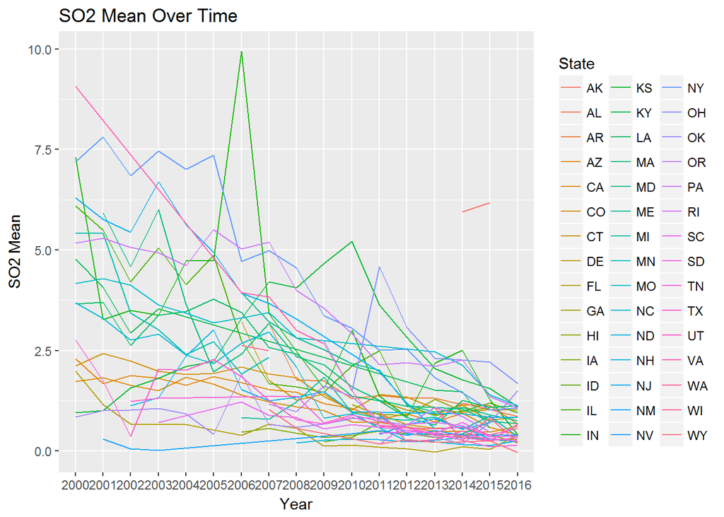

```r
pollution_avg %>%
  ggplot(mapping=aes(x=factor(Year),y=pollution_avg$`SO2 Mean`,group=State,color=State)) + geom_line() + ggtitle("SO2 Mean Over Time") + xlab("Year") + ylab("SO2 Mean")
```

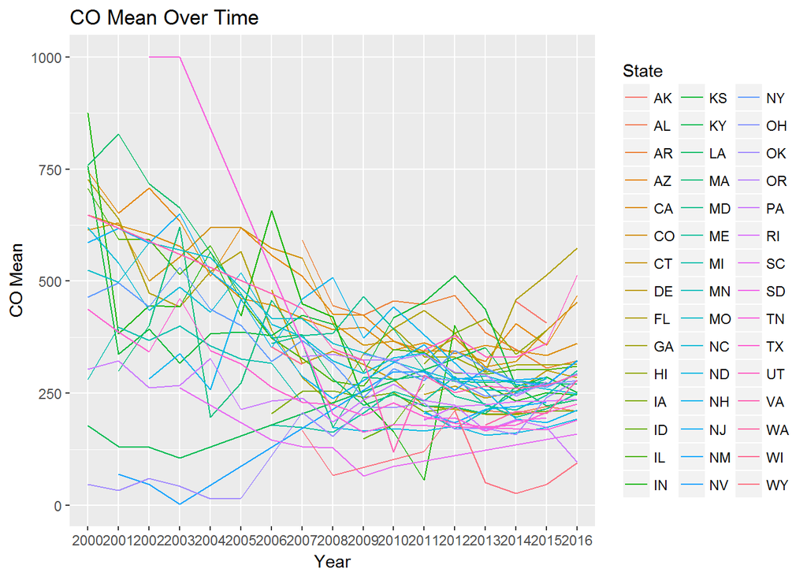

```r
pollution_avg %>%
  ggplot(mapping=aes(x=factor(Year),y=pollution_avg$`CO Mean`,group=State,color=State)) + geom_line() + ggtitle("CO Mean Over Time") + xlab("Year") + ylab("CO Mean")
```

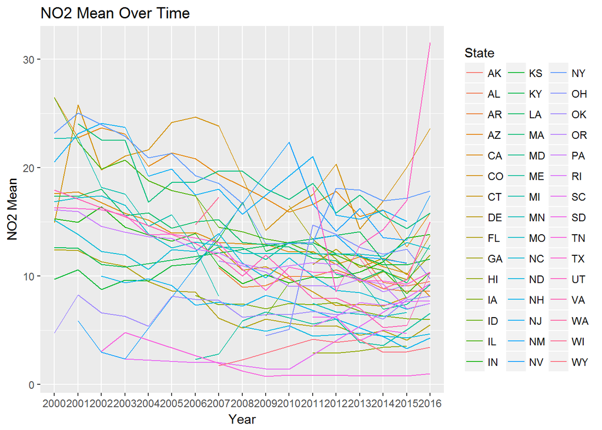

```r
pollution_avg %>%
  ggplot(mapping=aes(x=factor(Year),y=pollution_avg$`NO2 Mean`,group=State,color=State)) + geom_line() + ggtitle("NO2 Mean Over Time") + xlab("Year") + ylab("NO2 Mean")
```

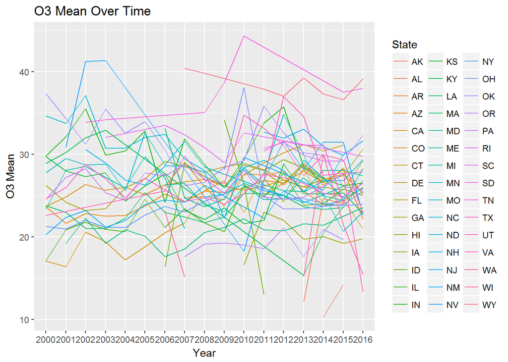

```r
pollution_avg %>%
  ggplot(mapping=aes(x=factor(Year),y=pollution_avg$`O3 Mean`,group=State,color=State)) + geom_line() + ggtitle("O3 Mean Over Time") + xlab("Year") + ylab("O3 Mean")
```

##Analysis The general trend for SO2 mean over the years is that it is decreasing over the years or staying generally low. There was a spike in 2006 which we call a outlier, but it then dropped very quickly during the next year. The general trend for CO mean over year was that it started high for most states and then steadily decreased. There seemed to be a slight increase after the year 2016, but we do not have data to support that speculation that just seems to be the general trend. NO2 mean over year does not seem to have a general, but there was a large spike in 2016. It also seems that NO2 is generally increasing in 2016. Lastly, O3 does not have a general trend and has stayed somewhat steady throughout the years. However, approaching 2016 it seems to be slightly increasing.

## AQI(Air quality index) Means over Year Line Plot

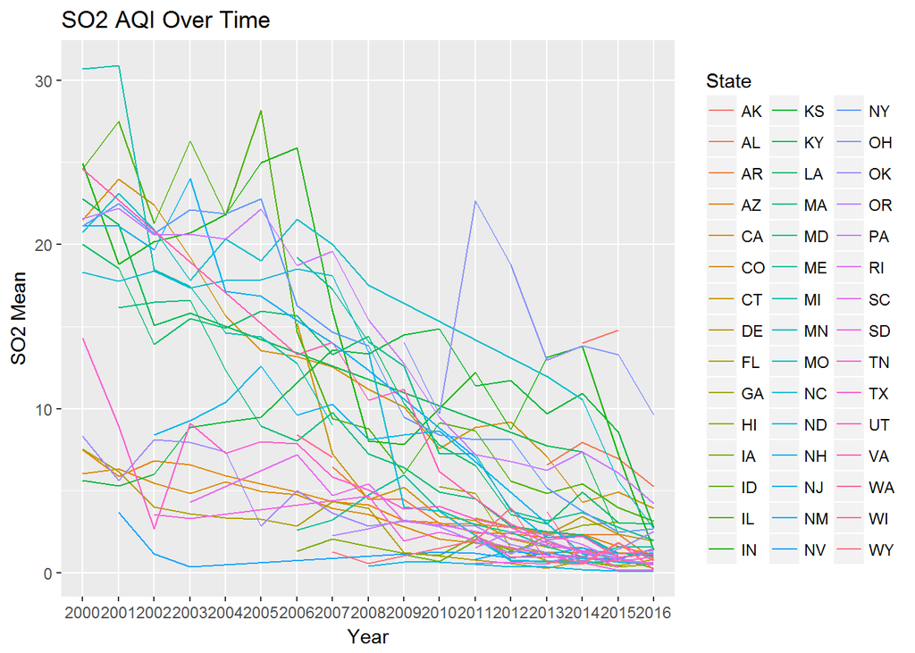

```r
pollution_avg %>%
  ggplot(mapping=aes(x=factor(Year),y=pollution_avg$`SO2 AQI`,group=State,color=State)) + geom_line() + ggtitle("SO2 AQI Over Time") + xlab("Year") + ylab("SO2 Mean")
```

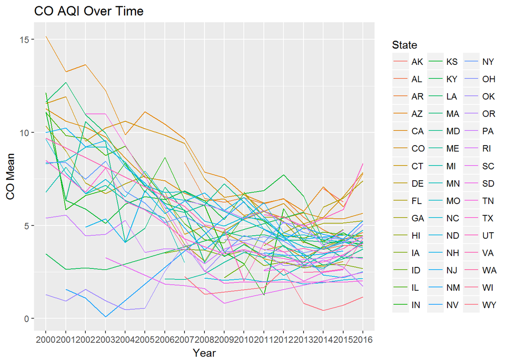

```r
pollution_avg %>%
  ggplot(mapping=aes(x=factor(Year),y=pollution_avg$`CO AQI`,group=State,color=State)) + geom_line() + ggtitle("CO AQI Over Time") + xlab("Year") + ylab("CO Mean")
```

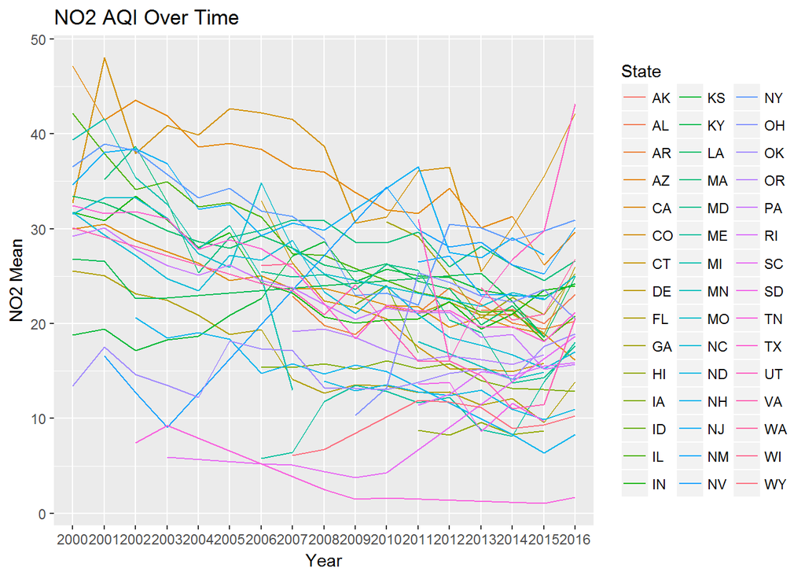

```r
pollution_avg %>%
  ggplot(mapping=aes(x=factor(Year),y=pollution_avg$`NO2 AQI`,group=State,color=State)) + geom_line() + ggtitle("NO2 AQI Over Time") + xlab("Year") + ylab("NO2 Mean")
```

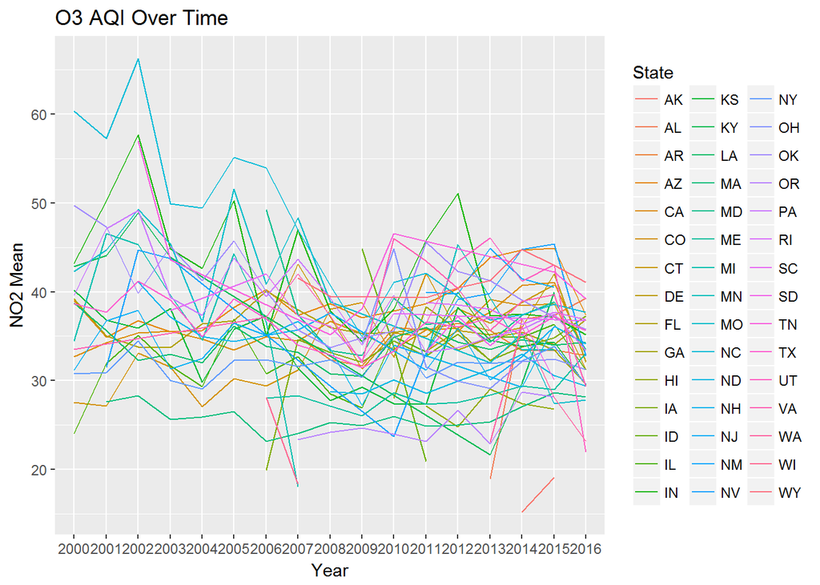

```r
pollution_avg %>%
  ggplot(mapping=aes(x=factor(Year),y=pollution_avg$`O3 AQI`,group=State,color=State)) + geom_line() + ggtitle("O3 AQI Over Time") + xlab("Year") + ylab("NO2 Mean")
```

## Violin Plots

The line plots before gave us a general idea of central trends and way to visualize our data. However, line plots may be difficult to read with so many states, so we can try using a violin plot.A violin plot is used to visualize the distribution of data and its proability density. This plot is a combination of a box plot and a density plot. We will plot pollutant concentration over time and pollutant air quality index over time. Also, with violin plots, instead of looking at pollution means and AQI means from each state we will be looking at the pollution means and AQI means as a whole for the U.S.. Below are some links for more information on violin plots.  
https://blog.modeanalytics.com/violin-plot-examples/  
https://en.wikipedia.org/wiki/Violin_plot

## Pollutant(SO2, CO, NO2, and O3) Means over Year Violin Plot

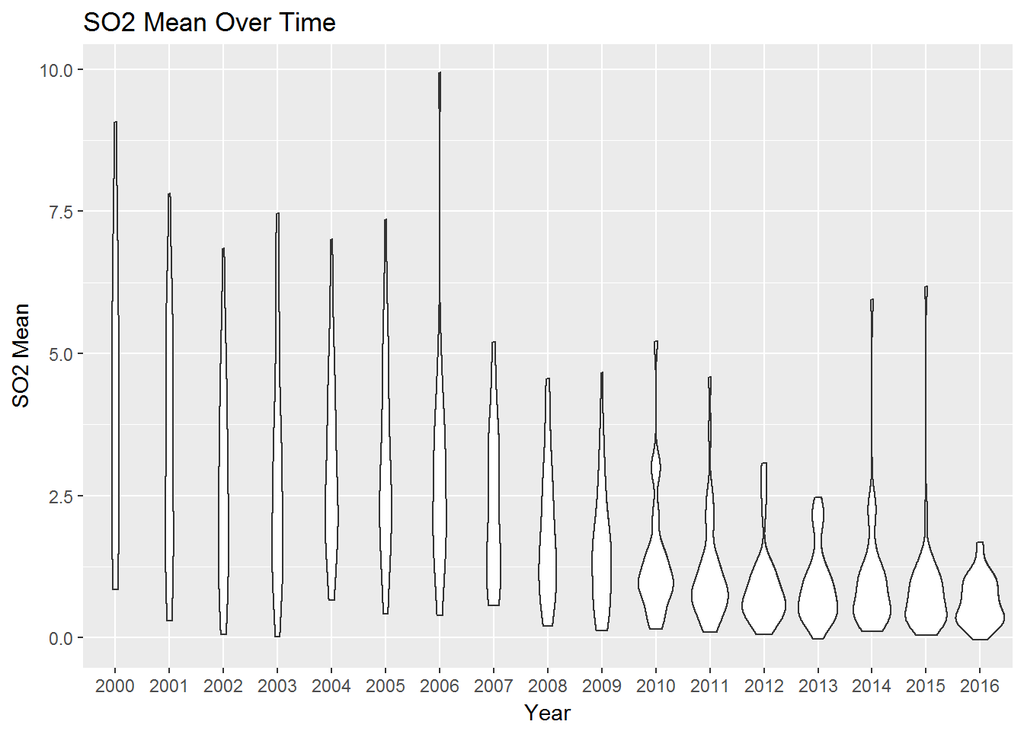

```r
pollution_avg %>%
  ggplot(mapping=aes(x=factor(Year),y=pollution_avg$`SO2 Mean`)) + geom_violin() + ggtitle("SO2 Mean Over Time") + xlab("Year") + ylab("SO2 Mean")
```

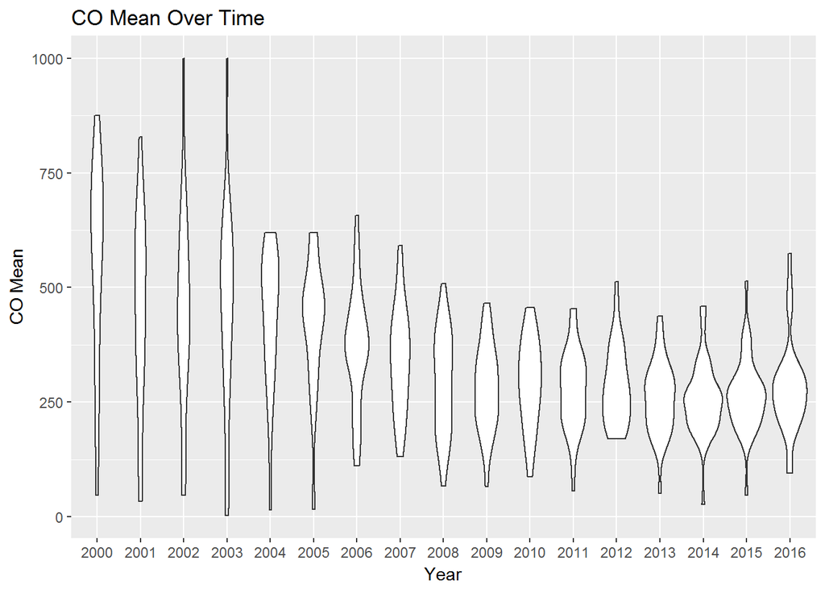

```r
pollution_avg %>%
  ggplot(mapping=aes(x=factor(Year),y=pollution_avg$`CO Mean`)) + geom_violin() + ggtitle("CO Mean Over Time") + xlab("Year") + ylab("CO Mean")
```

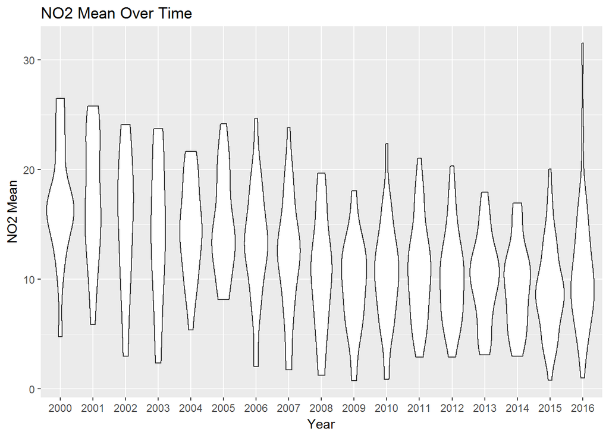

```r
pollution_avg %>%
  ggplot(mapping=aes(x=factor(Year),y=pollution_avg$`NO2 Mean`)) + geom_violin() + ggtitle("NO2 Mean Over Time") + xlab("Year") + ylab("NO2 Mean")
```

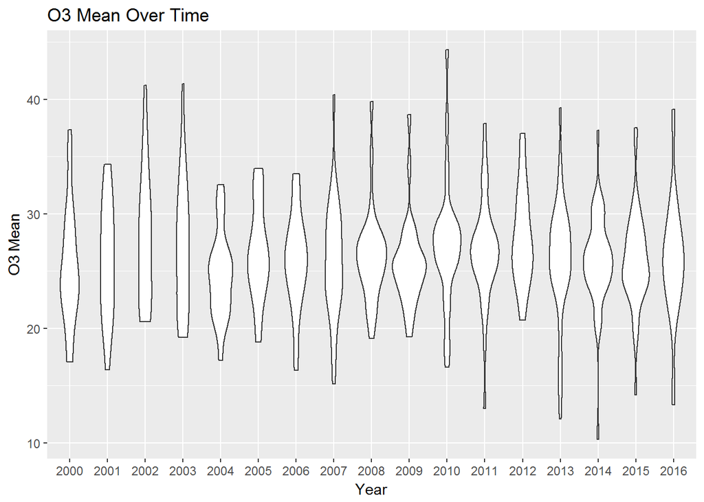

```r
pollution_avg %>%
  ggplot(mapping=aes(x=factor(Year),y=pollution_avg$`O3 Mean`)) + geom_violin() + ggtitle("O3 Mean Over Time") + xlab("Year") + ylab("O3 Mean")
```

The SO2 and CO have high variation in the early years and have a general trend of decreasing. CO also seems to have higher means. As years increase, SO2 decreases moreso than CO and there is less variation seen in both. The violin plots for NO2 and O3 show more variation when compared to SO2 and CO. There is no general trend and we can see that NO2 has stayed generally the same except that it started to increase as 2016 approached. O3 has also showen a slight increase.

## AQI(Air quality index) Means over Year Violin Plot

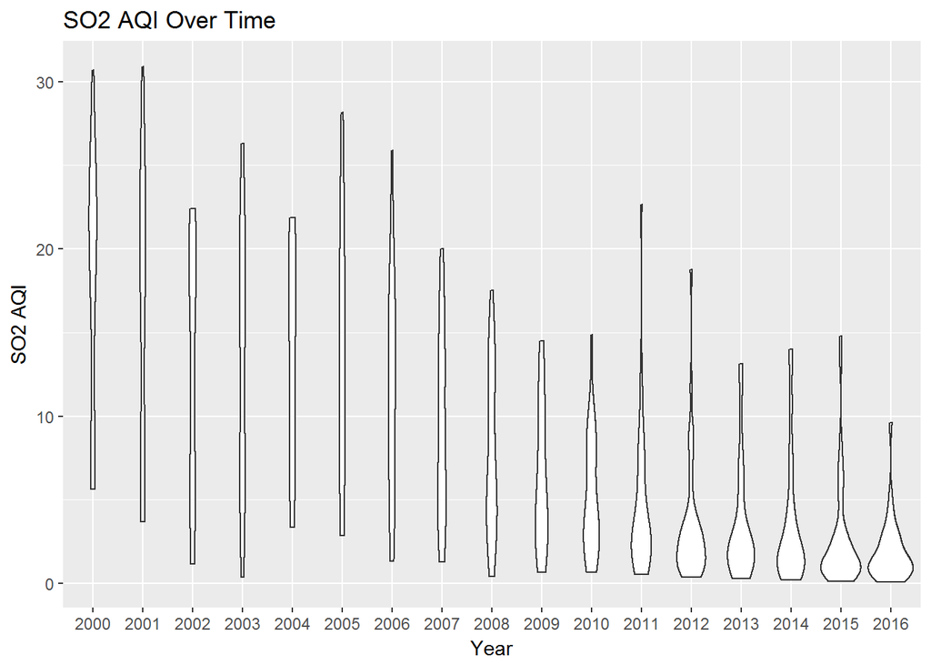

```r
pollution_avg %>%
  ggplot(mapping=aes(x=factor(Year),y=pollution_avg$`SO2 AQI`)) + geom_violin() + ggtitle("SO2 AQI Over Time") + xlab("Year") + ylab("SO2 AQI")
```

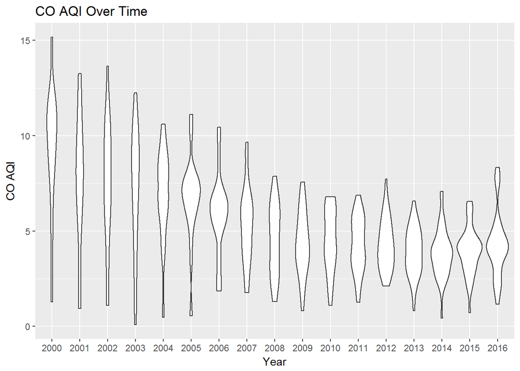

```r
pollution_avg %>%
  ggplot(mapping=aes(x=factor(Year),y=pollution_avg$`CO AQI`)) + geom_violin() + ggtitle("CO AQI Over Time") + xlab("Year") + ylab("CO AQI")
```

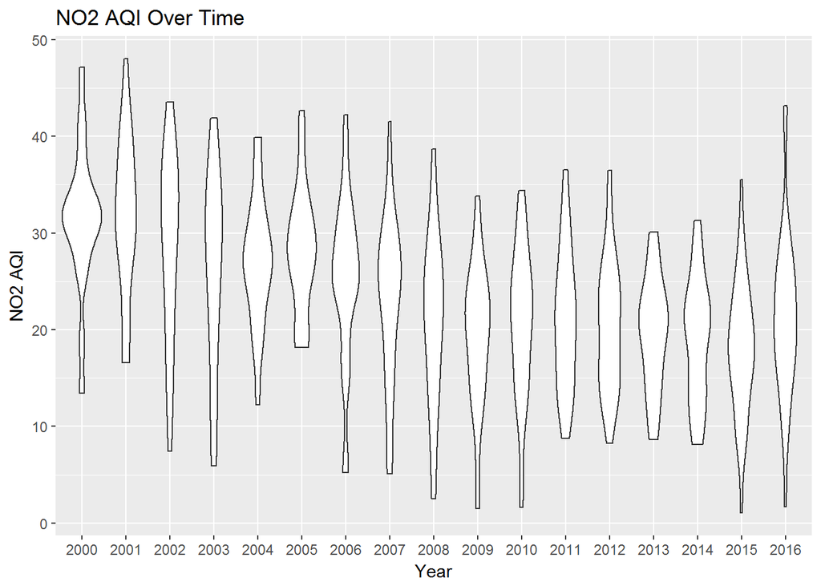

```r
pollution_avg %>%
  ggplot(mapping=aes(x=factor(Year),y=pollution_avg$`NO2 AQI`)) + geom_violin() + ggtitle("NO2 AQI Over Time") + xlab("Year") + ylab("NO2 AQI")
```

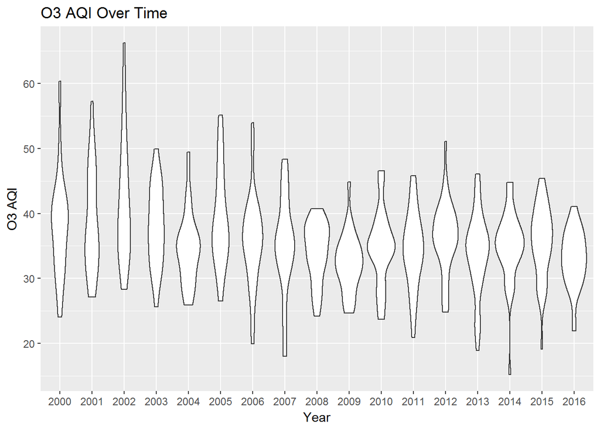

```r
pollution_avg %>%
  ggplot(mapping=aes(x=factor(Year),y=pollution_avg$`O3 AQI`)) + geom_violin() + ggtitle("O3 AQI Over Time") + xlab("Year") + ylab("O3 AQI")
```

The SO2 and CO have high variation in the early years, but the density tends to be low for SO2 and a little bit higher for CO. They both have a general trend of decreasing. CO seems to have a increasing density as the years increase but variation decreases greatly. As years increase, SO2’s variation decreases and the density becomes slightly concentrated near the bottom. The violin plots for NO2 and O3 show more variation when compared to SO2 and CO. There is no general trend and we can see that NO2 varies slightly, but the variation and distribution tend to stay the same for the most part. O3 shows a little less variation than NO2, but shows more variation.

## Map Plots

Another way we can analyze our data is by using a map plot of the U.S. since our data provides us with pollution from each state. This will help make our data more readable, while making it more intuitive since we are looking at data of the U.S. We’ll be using R’s function geom_map to create a map of the U.S.. Since we have data from 2000-2016, we’ll look at 3 years: 2000, 2008, and 2016. of course more years can be looked at but 8 year intervals in this case well for our data. Any state that has pollution data provided will be colored on the map. Any state that does not have pollution data will not be colored. We will have a legend that represents, the lighter the color of a state is, the more pollution they produced that year. The two boxes in the corner are for Alaska and Hawaii.

Sulfer Dioxide Pollution Levels by state for the years 2000, 2008, and 2016

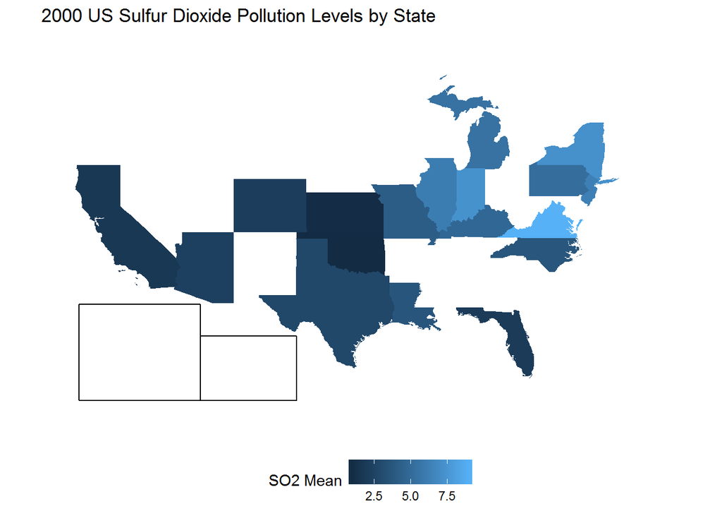

```r
library(ggplot2)
library(fiftystater)
library(dplyr)

data("fifty_states") # this line is optional due to lazy data loading

dataSO2_2000 <- pollution_avg %>%
  filter(Year == 2000)

dataSO2_2000$State <- tolower(state.name[match(dataSO2_2000$State,state.abb)])

# map_id creates the aesthetic mapping to the state name column in your data
p <- ggplot(dataSO2_2000, aes(map_id = dataSO2_2000$State)) +
  # map points to the fifty_states shape data
  geom_map(aes(fill = dataSO2_2000$'SO2 Mean'), map = fifty_states) +
  expand_limits(x = fifty_states$long, y = fifty_states$lat) +
  coord_map() +
  scale_x_continuous(breaks = NULL) +
  scale_y_continuous(breaks = NULL) +
  labs(x = "", y = "", fill="SO2 Mean") +
  theme(legend.position = "bottom",
        panel.background = element_blank()) + ggtitle("2000 US Sulfur Dioxide Pollution Levels by State")
p + fifty_states_inset_boxes()
```

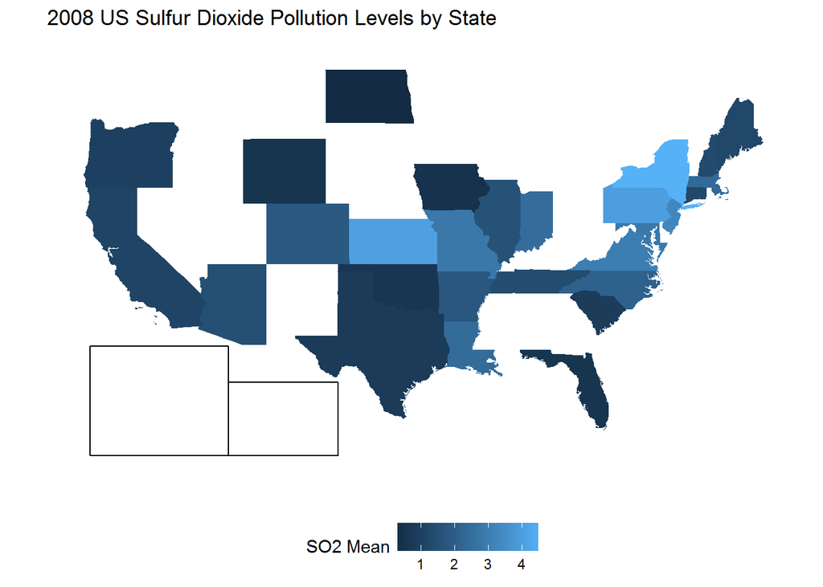

```r
dataSO2_2008 <- pollution_avg %>%
  filter(Year == 2008)

#2008 Data
dataSO2_2008$State <- tolower(state.name[match(dataSO2_2008$State,state.abb)])

# map_id creates the aesthetic mapping to the state name column in your data
p <- ggplot(dataSO2_2008, aes(map_id = dataSO2_2008$State)) +
  # map points to the fifty_states shape data
  geom_map(aes(fill = dataSO2_2008$'SO2 Mean'), map = fifty_states) +
  expand_limits(x = fifty_states$long, y = fifty_states$lat) +
  coord_map() +
  scale_x_continuous(breaks = NULL) +
  scale_y_continuous(breaks = NULL) +
  labs(x = "", y = "", fill="SO2 Mean") +
  theme(legend.position = "bottom",
        panel.background = element_blank()) + ggtitle("2008 US Sulfur Dioxide Pollution Levels by State")
p + fifty_states_inset_boxes()
```

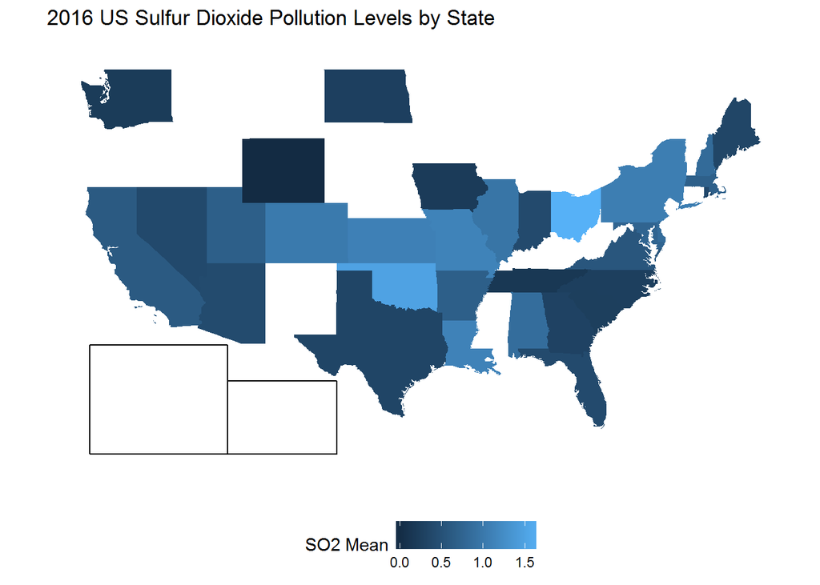

```r
#2016 Data
dataSO2_2016 <- pollution_avg %>%
  filter(Year == 2016)

dataSO2_2016$State <- tolower(state.name[match(dataSO2_2016$State,state.abb)])

# map_id creates the aesthetic mapping to the state name column in your data
p <- ggplot(dataSO2_2016, aes(map_id = dataSO2_2016$State)) +
  # map points to the fifty_states shape data
  geom_map(aes(fill = dataSO2_2016$'SO2 Mean'), map = fifty_states) +
  expand_limits(x = fifty_states$long, y = fifty_states$lat) +
  coord_map() +
  scale_x_continuous(breaks = NULL) +
  scale_y_continuous(breaks = NULL) +
  labs(x = "", y = "", fill="SO2 Mean") +
  theme(legend.position = "bottom",
        panel.background = element_blank()) + ggtitle("2016 US Sulfur Dioxide Pollution Levels by State")
p + fifty_states_inset_boxes()
```

Analysis for Sulfur Dioxide Levels by State  
In 2000, Virginia had the highest Sulfur Dioxide Concentration. In 2008, New York had the highest level. In 2016, Ohio had the highest level. We can determine this by looking how lightly colored these states are.